# Final Course Project

18 October 2018

## Predicting fuel economy for cars

### Using the R `mtcars` dataset

- Fuel economy is an essential attribute to consider when we consider buying a car
- In addition to savings, fuel economy of a car also plays an important role in terms of reducing carbon footprint
- Here is a model for predicting the fuel economy of a car based on some of its other attributes which are readily measurable
- The model is available as a Shiny App for use [here](https://krismaitra.shinyapps.io/finalcp/)
- Information about the data can be found in [R documentation](https://www.rdocumentation.org/packages/datasets/versions/3.5.1/topics/mtcars)

## The model

- A linear model is created `mpg` is the outcome variable vs. `hp`, `wt` and `am` as predictors
- The model is fitted and its coefficients and their P-values are given as follows:

```r
library(knitr)
fit <- lm(mpg ~  factor(am) + wt + hp, data = mtcars)
kable(t(summary(fit)$coef)[c(1,4),])
```

|  | (Intercept) | factor(am)1 | wt | hp |
| --- | --- | --- | --- | --- |
| Estimate | 34.00288 | 2.0837101 | -2.878575 | -0.0374787 |
| Pr(>\|t\|) | 0.00000 | 0.1412682 | 0.003574 | 0.0005464 |

## Model characteristics

| Characteristic | Value | Remarks |
| --- | --- | --- |
| R-squared | 0.84 | >0.5, Good fit |
| Model p-value | 2.90787154929718e-11 | Low p-value |
| F-statistic | 48.96 | Significant, with low p-value, Good fit |

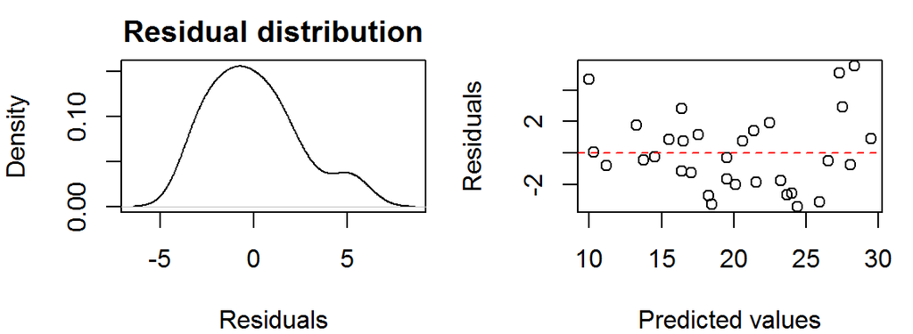

Residual errors in narrow range, almost normally distributed

The model charactersistics suggest that it is a reasonably good model to predict fuel economy  
The Shiny app uses this model to make its predictions  
It has a simple user interface and fantastic visualization  
Please do give it a try.  
**Please note:** The app may take some time to load the initial plot  
Thank you  
https://krismaitra.shinyapps.io/finalcp/